# Waste Analysis

### Annual waste analysis

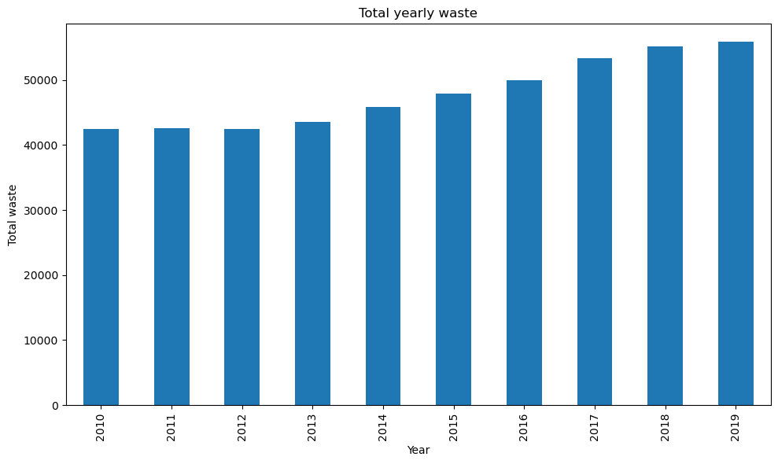

```python
total_yearly_waste = yearly_df_sum[['residential', 'public_litter_bins', 'dumped_rubbish', 'street_sweepings', 'mattresses', 'commingled_recycling', 'cardboard', 'green_waste']].sum(axis=1)

plt.figure(figsize=(10, 6))
total_yearly_waste.iloc[1:11].plot(kind='bar')
plt.title('Total yearly waste')
plt.xlabel('Year')
plt.ylabel('Total waste')
plt.xticks(range(10), yearly_df.loc[1:10,'year'])
plt.tight_layout()
plt.show()
```

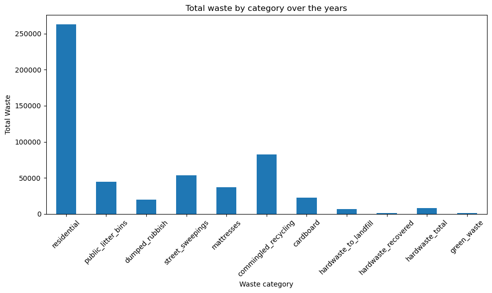

```python
total_waste = yearly_df_sum[cols].sum(axis=0)

plt.figure(figsize=(10, 6))
total_waste.plot(kind='bar')
plt.title('Total waste by category over the years')
plt.xlabel('Waste category')
plt.ylabel('Total Waste')
plt.xticks(rotation=45)
plt.tight_layout()  # Adjust layout to prevent overlapping elements
plt.show()
```

### Yearly average waste composition (2010, 2015, 2019)

The three piecharts below represent the yearly mean waste in 2010, 2015 and 2019. Residential waste covers majority of the percentage and has increased over the years. Cardboard waste, street sweepings and dumped rubbish has decreased significantly over the years.

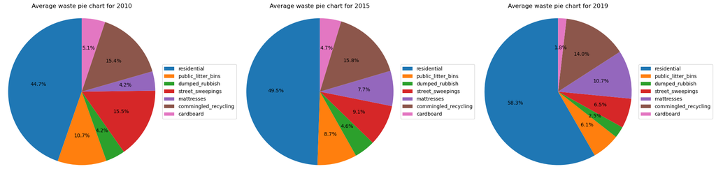

```python
cols = ['residential','public_litter_bins','dumped_rubbish','street_sweepings',	'mattresses','commingled_recycling','cardboard']
fig, axs = plt.subplots(1, 3, figsize=(20, 5))
for i, year in enumerate(['2010', '2015', '2019']):
    ax = axs[i]
    ax.set_title(f'Average waste pie chart for {year}')
    year_data = yearly_df_avg[yearly_df_avg['year']==year]

    sizes = year_data[cols].values[0]
    ax.pie(sizes, autopct='%1.1f%%', startangle=90)
    ax.axis('equal')
    ax.legend(cols, loc="center left", bbox_to_anchor=(1, 0, 0.5, 1))

plt.tight_layout()
plt.show()
```

### Trend analysis of yearly average waste (2009-2020)

**Street sweepings** It can be seen that street sweeping waste has significantly decreased over the years and continues to follow a downward liniear trend. The amount from 2009 to 2020 is almost less than half.

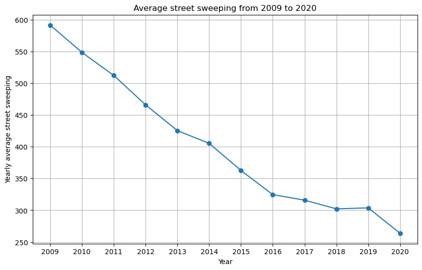

```python
plt.figure(figsize=(10, 6))
plt.plot(yearly_df_avg['year'], yearly_df_avg['street_sweepings'], marker='o')
plt.xlabel('Year')
plt.ylabel('Yearly average street sweeping')
plt.title('Average street sweeping from 2009 to 2020')
plt.grid(True)

plt.show()
```

**Residential waste** It can be seen that residential waste has significantly increased over the years and continued in an upward liniear trend till 2019. It seems to decrease from 2020. The amount in 2020 is almost twice as much it was in 2009.

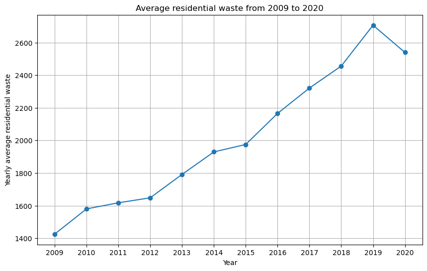

```python
plt.figure(figsize=(10, 6))
plt.plot(yearly_df_avg['year'], yearly_df_avg['residential'], marker='o')
plt.xlabel('Year')
plt.ylabel('Yearly average residential waste')
plt.title('Average residential waste from 2009 to 2020')
plt.grid(True)
plt.show()
```

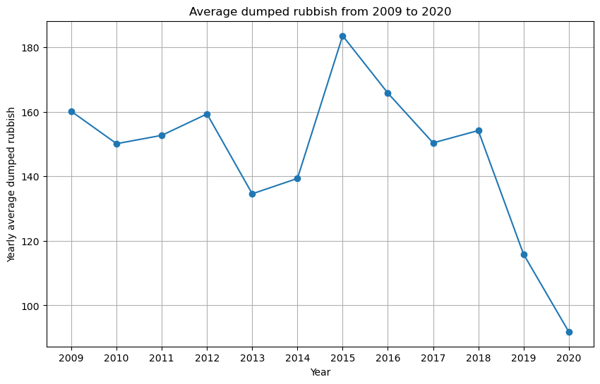

```python
plt.figure(figsize=(10, 6))
plt.plot(yearly_df_avg['year'], yearly_df_avg['dumped_rubbish'], marker='o')
plt.xlabel('Year')
plt.ylabel('Yearly average dumped rubbish')
plt.title('Average dumped rubbish from 2009 to 2020')
plt.grid(True)
plt.show()
```

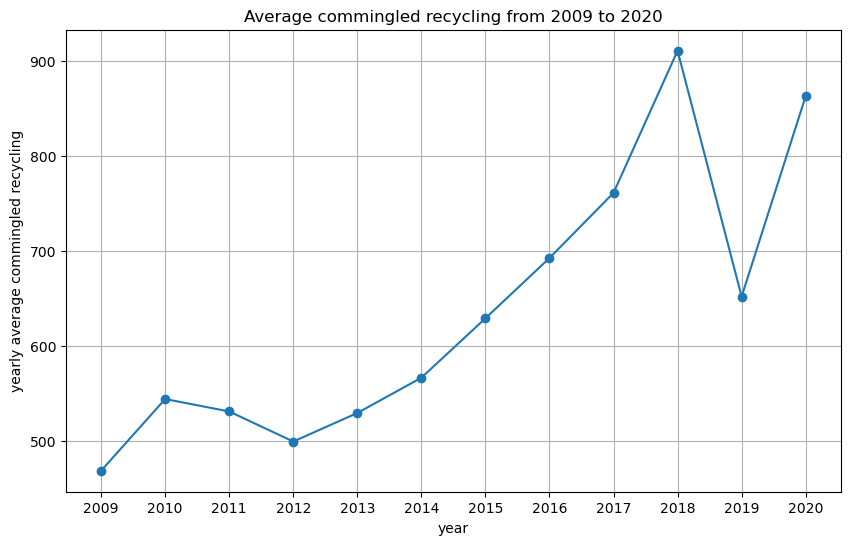

```python
plt.figure(figsize=(10, 6))
plt.plot(yearly_df_avg['year'], yearly_df_avg['commingled_recycling'], marker='o')
plt.xlabel('year')
plt.ylabel('yearly average commingled recycling')
plt.title('Average commingled recycling from 2009 to 2020')
plt.grid(True)
plt.show()
```

### Correlation analysis between residential waste vs public litter bins and residential waste vs street sweepings

It can be seen that the yearly average of residential waste and public litter bins have a highe negative correlated of 76% which can also be seen from the scatter plot. The increase in residential waste is likely to cause the decrease in public litter bin waste since people are likely using garbage bins at home instead.

```python
correlation_coefficient = yearly_df_avg['residential'].corr(yearly_df_avg['public_litter_bins'])
print("Correlation coefficient:", correlation_coefficient)
```

```
Correlation coefficient: -0.7573120022638253
```

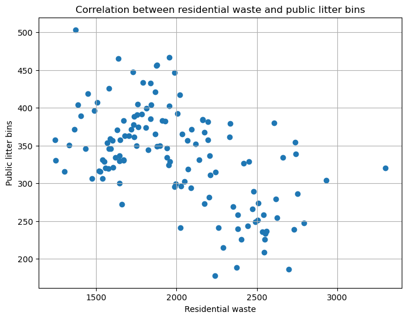

```python
plt.figure(figsize=(8, 6))
plt.scatter(waste_df['residential'], waste_df['public_litter_bins'])
plt.xlabel('Residential waste')
plt.ylabel('Public litter bins')
plt.title('Correlation between residential waste and public litter bins')
plt.grid(True)
plt.show()
```

There is an even stronger negative correlation of 94% between the average residential waste and street sweeping waste which can also be seen from the scatter plot.

```python
correlation_coefficient = yearly_df_avg['residential'].corr(yearly_df_avg['street_sweepings'])
print("Correlation coefficient:", correlation_coefficient)
```

```
Correlation coefficient: -0.938964624436597
```

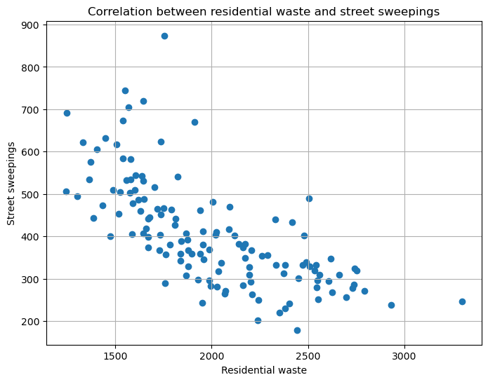

```python
plt.figure(figsize=(8, 6))
plt.scatter(waste_df['residential'], waste_df['street_sweepings'])
plt.xlabel('Residential waste')
plt.ylabel('Street sweepings')
plt.title('Correlation between residential waste and street sweepings')
plt.grid(True)
plt.show()
```